# **EasyVisa_Predicting Visa Approval Outcomes Using Advanced Machine Learning Techniques**

#### **Pairwise feature relationships and distribution analysis by case_status**

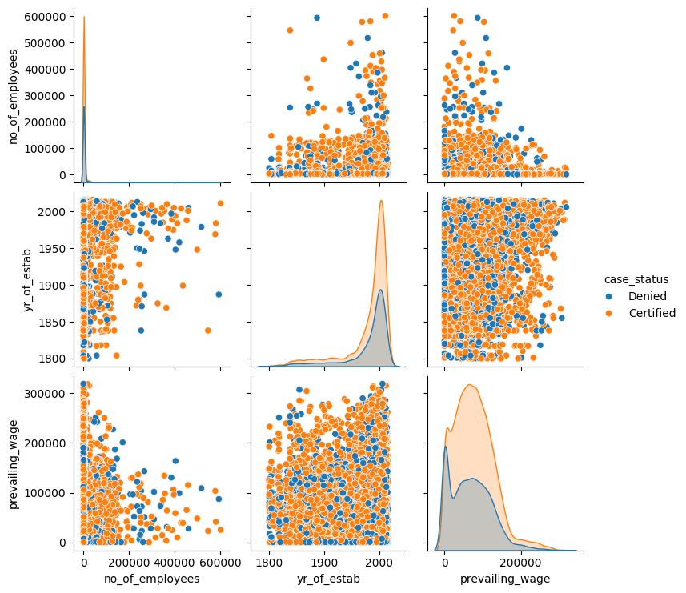

```python
# Visualizing relationships among numerical variables by case status
sns.pairplot(visa_df, vars = numerical_variables, hue = 'case_status', diag_kind = 'kde')
plt.show()
```

**`Observations:`**

- The pairplot shows that the numerical variables do not have a strong linear separation between Certified and Denied cases.
- The no_of_employees variable is highly right skewed, with most companies having a smaller employee count and a few companies having extremely large employee counts.
- The yr_of_estab variable is concentrated around more recent years, especially after 1950, indicating that many employers were established in recent decades.
- The prevailing_wage distribution is also right skewed, with most values concentrated at lower wage levels and fewer observations at very high wage levels.
- Certified and Denied cases overlap heavily across all numerical variable combinations, suggesting that these numerical variables alone may not clearly distinguish the target classes.
- This indicates that the classification model should rely on a combination of numerical and categorical predictors rather than depending only on numerical features.

#### **Correlation Matrix of Numerical Variables**

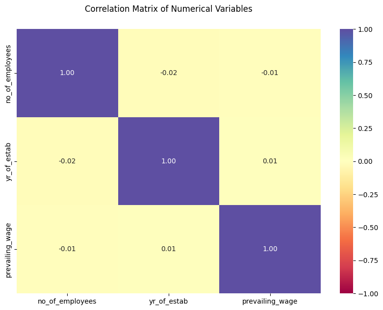

```python
# Plotting correlation matrix for numerical variables
plt.figure(figsize = (10, 7))
sns.heatmap(visa_df[numerical_variables].corr(), annot = True, cmap = 'Spectral', vmin = -1, vmax = 1, cbar = True, fmt = '.2f')
plt.title('Correlation Matrix of Numerical Variables', y = 1.05)
plt.show()
```

**`Observations:`**

- The correlation matrix shows that there is almost no linear relationship among the numerical variables in the dataset.
- The correlation between no_of_employees and yr_of_estab is very weak and slightly negative at -0.02.
- The correlation between no_of_employees and prevailing_wage is also very weak and slightly negative at -0.01.
- The correlation between yr_of_estab and prevailing_wage is very weak and slightly positive at 0.01.
- Overall, there is no evidence of multicollinearity among the numerical variables, so all three numerical features can be retained for model building.

# **Data Pre-Processing**

## **Check the percentage of outliers in the Numerical Variables**

```python
# Calculating IQR based lower and upper limits for numerical outlier detection
Q1 = visa_df[numerical_variables].quantile(0.25)
Q3 = visa_df[numerical_variables].quantile(0.75)

IQR = Q3 - Q1

lower_bound = Q1 - 1.5 * IQR
upper_bound = Q3 + 1.5 * IQR
```

```python
# Calculating percentage of outliers in each numerical variable
outliers_percentage = (((visa_df[numerical_variables] < lower_bound) | (visa_df[numerical_variables] > upper_bound)).sum() / visa_df.shape[0]) * 100

print(f'Percentage of outliers in the numerical variables: \n{outliers_percentage}')
```

```
Percentage of outliers in the numerical variables:
no_of_employees     6.106750
yr_of_estab        12.794349
prevailing_wage     1.675824
dtype: float64
```

**`Observations:`**

- The outliers in the numerical variables were not treated because they appear to represent valid real world variations rather than incorrect or impossible values.
- For no_of_employees, the outlier percentage is around 6.11%. Since company sizes can naturally vary from very small employers to very large organizations, extreme employee counts may carry useful information about the employer profile and should not be removed unnecessarily.
- For yr_of_estab, the outlier percentage is around 12.79%. These values represent older companies, which are valid observations. Treating or capping them could remove important information related to the age and stability of an employer.
- For prevailing_wage, the outlier percentage is only around 1.68%. Wage values can vary based on job role, skill level, region of employment, and unit of wage, so these high or low wage values may be meaningful for predicting visa approval outcomes.
- Also, the models used in this project are tree based ensemble models such as Random Forest, Bagging, AdaBoost, Gradient Boosting, and XGBoost. These models are generally less sensitive to outliers compared to distance based or linear models.
- Therefore, the outliers were retained to preserve the natural variability in the data and avoid losing potentially important patterns that could help the classification models make better predictions.

## **Data preparation for model buidling**

```python
# Dropping unique identifier column
visa_df.drop(['case_id'], axis = 1, inplace = True)

# Encoding target variable into binary values
visa_df['case_status'] = visa_df['case_status'].map({'Denied': 0, 'Certified': 1})

# Separating independent variables and target variable
X = visa_df.drop(['case_status'], axis = 1)
y = visa_df['case_status']

# Encoding categorical variables using one-hot encoding
X = pd.get_dummies(X, drop_first = True)

# Converting all feature columns to float type
X = X.astype(float)
```

**`Observations:`**

- The case_id column was dropped because it is a unique identifier and does not provide predictive value for model building.
- The target variable case_status was encoded into binary values, where Denied was mapped to 0 and Certified was mapped to 1.
- The dataset was separated into independent variables X and the target variable y to prepare it for supervised machine learning.
- Categorical variables were converted into numerical format using one hot encoding so that they could be used by machine learning models.
- The feature columns were converted to float data type to maintain consistency across all input variables before model training.
- The prevailing_wage column was not separately treated based on unit_of_wage because the wage unit information was retained as a categorical feature and encoded during data preparation.
- After one hot encoding, the model can learn the relationship between prevailing_wage and different wage units such as Hour, Week, Month, and Year.
- Since tree based models were used, they can handle variations and non linear patterns across wage groups without requiring manual conversion of all wages into a single unit.
- Also, changing or standardizing prevailing_wage manually could introduce assumptions and distort the original wage information present in the dataset.
- Therefore, both prevailing_wage and unit_of_wage were kept as separate features so the model could learn their combined effect on visa approval outcomes.

## **Splitting the data into Training, Validation, and Test sets**

```python
# Splitting data into training and test sets
X_temp, X_test, y_temp, y_test = train_test_split(
    X,
    y,
    test_size = 0.2,
    random_state = 42,
    stratify = y
)

# Splitting training data into training and validation sets
X_train, X_val, y_train, y_val = train_test_split(
    X_temp,
    y_temp,
    test_size = 0.2,
    random_state = 42,
    stratify = y_temp
)
```

```python
# Checking dataset shapes and class distribution after splitting
print('Shape of the Training Set:', X_train.shape)
print('Shape of the Validation Set:', X_val.shape)
print('Shape of the Test Set:', X_test.shape)

# Checking class balance in training, validation, and test sets
print('Percentage of classes in the Training Set:')
print(y_train.value_counts(normalize = True))

print('Percentage of classes in the Validation Set:')
print(y_val.value_counts(normalize = True))

print('Percentage of classes in the Test Set:')
print(y_test.value_counts(normalize = True))
```

```
Shape of the Training Set: (16307, 21)
Shape of the Validation Set: (4077, 21)
Shape of the Test Set: (5096, 21)
Percentage of classes in the Training Set:
case_status
1    0.667873
0    0.332127
Name: proportion, dtype: float64
Percentage of classes in the Validation Set:
case_status
1    0.667893
0    0.332107
Name: proportion, dtype: float64
Percentage of classes in the Test Set:
case_status
1    0.667975
0    0.332025
Name: proportion, dtype: float64
```

**`Observations:`**

- The dataset was split into three parts with 16307 records in the training set, 4077 records in the validation set, and 5096 records in the test set.
- Each dataset contains 21 input features after removing the target variable and applying one hot encoding to categorical variables.
- The class distribution is consistent across all three datasets, with approximately 66.8 percent Certified cases and 33.2 percent Denied cases.
- This confirms that stratified splitting worked correctly because the target class proportions were preserved in the training, validation, and test sets.
- The dataset shows moderate class imbalance, as Certified cases are nearly twice the number of Denied cases, which justifies the use of techniques such as SMOTE or undersampling during model training.

# **Model evaluation criteria**

```python
# Function to calculate classification model performance metrics
def model_performance_evaluation(model, predictors, target):

  """
  Function to compute different metrics to check classification model performance

  model: classifier
  predictors: independent variables
  target: dependent variable
  """

  # Predicting target values
  y_pred = model.predict(predictors)

  # Calculating performance metrics
  accuracy = accuracy_score(target, y_pred)
  precision  = precision_score(target, y_pred)
  recall = recall_score(target, y_pred)
  f1 = f1_score(target, y_pred)

  # Storing metrics in a dataframe
  df_perf = pd.DataFrame({
      'Accuracy': accuracy,
      'Precision': precision,
      'Recall': recall,
      'F1 Score': f1},
      index = [0]
      )

  return df_perf
```

```python
# Function to plot confusion matrix with count and percentage labels
def confusion_matrix(model, predictors, target):
    """
    To plot the confusion_matrix with percentages

    model: classifier
    predictors: independent variables
    target: dependent variable
    """

    # Predicting target values
    y_pred = model.predict(predictors)

    # Creating confusion matrix
    cm = metrics.confusion_matrix(target, y_pred)

    # Creating count and percentage labels
    labels = np.asarray(
        [
            ["{0:0.0f}".format(item) + "\n{0:.2%}".format(item / cm.flatten().sum())]
            for item in cm.flatten()
        ]
    ).reshape(2, 2)

    # Plotting confusion matrix heatmap
    plt.figure(figsize=(6, 4))
    sns.heatmap(cm, annot=labels, fmt="")
    plt.ylabel("True label")
    plt.xlabel("Predicted label")
```

# **Model building**

```python
# Creating a list of classification models
models = []

models.append(('Bagging Classifier', BaggingClassifier(random_state = 42)))
models.append(('Random Forest Classifier', RandomForestClassifier(random_state = 42)))
models.append(('Adaboost Classifier', AdaBoostClassifier(random_state = 42)))
models.append(('Gradient Boosting Classifier', GradientBoostingClassifier(random_state = 42)))
models.append(('XGBoost Classifier', XGBClassifier(random_state = 42)))

# Training each model and evaluating performance on training and validation sets
for name, model in models:
  model.fit(X_train, y_train)

  print(name)
  print('\nTraining Performane:')
  print(model_performance_evaluation(model, X_train, y_train))

  print('\nValidation Performance:')
  print(model_performance_evaluation(model, X_val, y_val))

  print('-' * 120)
```

```
Bagging Classifier

Training Performane:
   Accuracy  Precision    Recall  F1 Score
0  0.986018   0.992244  0.986778  0.989504

Validation Performance:
   Accuracy  Precision    Recall  F1 Score
0   0.69561   0.767702  0.780389  0.773994
------------------------------------------------------------------------------------------------------------------------
Random Forest Classifier

Training Performane:
   Accuracy  Precision  Recall  F1 Score
0       1.0        1.0     1.0       1.0

Validation Performance:
   Accuracy  Precision    Recall  F1 Score
0  0.721118   0.766107  0.838414  0.800631
------------------------------------------------------------------------------------------------------------------------
Adaboost Classifier

Training Performane:
   Accuracy  Precision    Recall  F1 Score
0  0.741951   0.766149  0.883206  0.820524

Validation Performance:
   Accuracy  Precision    Recall  F1 Score
0  0.734609   0.757291  0.886889  0.816982
------------------------------------------------------------------------------------------------------------------------
Gradient Boosting Classifier

Training Performane:
   Accuracy  Precision   Recall  F1 Score
0  0.757895   0.785321  0.87733   0.82878

Validation Performance:
   Accuracy  Precision    Recall  F1 Score
0   0.74859   0.775828  0.876974  0.823306
------------------------------------------------------------------------------------------------------------------------
XGBoost Classifier

Training Performane:
   Accuracy  Precision    Recall  F1 Score
0  0.849635    0.85354  0.935359  0.892579

Validation Performance:
   Accuracy  Precision    Recall  F1 Score
0  0.734118   0.769484  0.859346  0.811936
------------------------------------------------------------------------------------------------------------------------
```

**`Observations:`**

- The Bagging Classifier shows very high training performance with an F1 Score of 0.9895, but its validation F1 Score drops to 0.7740. This indicates strong overfitting because the model performs extremely well on training data but does not generalize equally well to unseen data.
- The Random Forest Classifier achieves perfect training performance with Accuracy, Precision, Recall, and F1 Score all equal to 1.0000. However, its validation F1 Score decreases to 0.8006, which also suggests overfitting.
- The AdaBoost Classifier performs more consistently across training and validation sets. Its training F1 Score is 0.8205 and validation F1 Score is 0.8170, showing that the model generalizes well without major overfitting.
- The Gradient Boosting Classifier gives the best validation performance among these models, with a validation Accuracy of 0.7486 and F1 Score of 0.8233. The small difference between training and validation performance indicates stable model behavior.
- The XGBoost Classifier has a high training F1 Score of 0.8926 but a lower validation F1 Score of 0.8119. This suggests moderate overfitting compared to AdaBoost and Gradient Boosting.
- Overall, Gradient Boosting appears to be the best performing base model because it provides the highest validation Accuracy and F1 Score while maintaining a reasonable balance between training and validation performance.

# **Model building - Over sampled data**

```python
# Checking class counts before oversampling
print("Before Oversampling, count of label 'Certified': {}".format(sum(y_train == 1)))
print("Before Oversampling, count of label 'Denied': {} \n".format(sum(y_train == 0)))

# Applying SMOTE to balance the training data
sm = SMOTE(sampling_strategy = 1, k_neighbors = 5, random_state = 42)
X_train_over, y_train_over = sm.fit_resample(X_train, y_train)

# Checking class counts after oversampling
print("After Oversampling, count of label 'Certified': {}".format(sum(y_train_over == 1)))
print("After Oversampling, count of label 'Denied': {} \n".format(sum(y_train_over == 0)))

# Checking the shape of oversampled training data
print("After Oversampling, the shape of X_train: {}".format(X_train_over.shape))
print("After Oversampling, the shape of y_train: {} \n".format(y_train_over.shape))
```

```
Before Oversampling, count of label 'Certified': 10891
Before Oversampling, count of label 'Denied': 5416

After Oversampling, count of label 'Certified': 10891
After Oversampling, count of label 'Denied': 10891

After Oversampling, the shape of X_train: (21782, 21)
After Oversampling, the shape of y_train: (21782,)
```

**`Observations:`**

- Before oversampling, the training data was imbalanced with 10891 Certified cases and 5416 Denied cases.
- The Certified class had almost double the number of records compared to the Denied class, which could make the model biased toward predicting Certified cases more often.
- SMOTE was applied only on the training data to balance the class distribution without affecting the validation and test sets.
- After oversampling, both Certified and Denied classes have 10891 records each, creating a balanced training dataset.
- The shape of the training data increased from 16307 rows to 21782 rows, while the number of features remained the same at 21.
- This balanced dataset can help the model learn patterns from both classes more fairly and improve its ability to identify Denied cases.

```python
# Creating a list of models for oversampled training data
models = []


models.append(('Bagging Classifier Over', BaggingClassifier(random_state = 42)))
models.append(('Random Forest Classifier Over', RandomForestClassifier(random_state = 42)))
models.append(('Adaboost Classifier Over', AdaBoostClassifier(random_state = 42)))
models.append(('Gradient Boosting Classifier Over', GradientBoostingClassifier(random_state = 42)))
models.append(('XGBoost Classifier Over', XGBClassifier(random_state = 42)))

# Training each model on oversampled data and evaluating performance
for name, model in models:
  model.fit(X_train_over, y_train_over)

  print(name)
  print('\nTraining Performane:')
  print(model_performance_evaluation(model, X_train_over, y_train_over))

  print('\nValidation Performance:')
  print(model_performance_evaluation(model, X_val, y_val))

  print('-' * 120)
```

```
Bagging Classifier Over

Training Performane:
   Accuracy  Precision    Recall  F1 Score
0  0.987834   0.991853  0.983748  0.987784

Validation Performance:
   Accuracy  Precision   Recall  F1 Score
0  0.699534   0.772959  0.77892  0.775928
------------------------------------------------------------------------------------------------------------------------
Random Forest Classifier Over

Training Performane:
   Accuracy  Precision  Recall  F1 Score
0       1.0        1.0     1.0       1.0

Validation Performance:
   Accuracy  Precision    Recall  F1 Score
0  0.722835   0.767731  0.838781  0.801685
------------------------------------------------------------------------------------------------------------------------
Adaboost Classifier Over

Training Performane:
   Accuracy  Precision    Recall  F1 Score
0  0.797034   0.781158  0.825269  0.802607

Validation Performance:
   Accuracy  Precision    Recall  F1 Score
0  0.726515   0.776669  0.828865  0.801919
------------------------------------------------------------------------------------------------------------------------
Gradient Boosting Classifier Over

Training Performane:
   Accuracy  Precision    Recall  F1 Score
0  0.814434   0.785875  0.864383  0.823262

Validation Performance:
   Accuracy  Precision    Recall  F1 Score
0  0.747363   0.779281  0.867426  0.820994
------------------------------------------------------------------------------------------------------------------------
XGBoost Classifier Over

Training Performane:
   Accuracy  Precision    Recall  F1 Score
0  0.878845   0.846898  0.924892  0.884178

Validation Performance:
   Accuracy  Precision    Recall  F1 Score
0  0.735345      0.774  0.852736  0.811463
------------------------------------------------------------------------------------------------------------------------
```

**`Observations:`**

- The models were trained using the oversampled training data where both Certified and Denied classes were balanced using SMOTE.
- Random Forest achieved perfect training performance with 1.00 accuracy, precision, recall, and F1 score, but its validation F1 score was 0.8017, indicating overfitting.
- Bagging Classifier also showed very high training performance with an F1 score of 0.9878, but its validation F1 score dropped to 0.7759, showing that it did not generalize well.
- Gradient Boosting Classifier gave the best validation performance among the oversampled models with an accuracy of 0.7474 and F1 score of 0.8210.
- XGBoost showed strong training performance with an F1 score of 0.8842, but its validation F1 score was 0.8115, which is slightly lower than Gradient Boosting.
- AdaBoost performed consistently with a validation F1 score of 0.8019, but it was still lower than Gradient Boosting and XGBoost.
- Overall, Gradient Boosting Classifier appears to be the best performing model on the oversampled data because it provides the highest validation F1 score with a relatively smaller gap between training and validation performance.

# **Model building - Under sampled data**

```python
# Checking class counts before undersampling
print("Before Undersampling, count of label 'Certified': {}".format(sum(y_train == 1)))
print("Before Undersampling, count of label 'Denied': {} \n".format(sum(y_train == 0)))

# Applying random undersampling to balance the training data
rus = RandomUnderSampler(random_state = 42)
X_train_under, y_train_under = rus.fit_resample(X_train, y_train)

# Checking class counts after undersampling
print("After Undersampling, count of label 'Certified': {}".format(sum(y_train_under == 1)))
print("After Undersampling, count of label 'Denied': {} \n".format(sum(y_train_under == 0)))

# Checking the shape of undersampled training data
print("After Undersampling, the shape of X_train: {}".format(X_train_under.shape))
print("After Undersampling, the shape of y_train: {} \n".format(y_train_under.shape))
```

```
Before Undersampling, count of label 'Certified': 10891
Before Undersampling, count of label 'Denied': 5416

After Undersampling, count of label 'Certified': 5416
After Undersampling, count of label 'Denied': 5416

After Undersampling, the shape of X_train: (10832, 21)
After Undersampling, the shape of y_train: (10832,)
```

**`Observations:`**

- Before undersampling, the training data had 10,891 Certified records and 5,416 Denied records, showing that the dataset was imbalanced toward the Certified class.
- Random undersampling was applied to balance the class distribution by reducing the majority class, Certified, to match the minority class, Denied.
- After undersampling, both Certified and Denied classes contain 5,416 records each, creating a perfectly balanced training dataset.
- The final undersampled training dataset contains 10,832 rows and 21 feature columns.
- Although undersampling balances the classes, it reduces the size of the training data by removing many Certified records, which may lead to loss of useful information.

```python
# Creating a list of models for undersampled training data
models = []

models.append(('Bagging Classifier Under', BaggingClassifier(random_state = 42)))
models.append(('Random Forest Classifier Under', RandomForestClassifier(random_state = 42)))
models.append(('Adaboost Classifier Under', AdaBoostClassifier(random_state = 42)))
models.append(('Gradient Boosting Classifier Under', GradientBoostingClassifier(random_state = 42)))
models.append(('XGBoost Classifier Under', XGBClassifier(random_state = 42)))

# Training each model on undersampled data and evaluating performance
for name, model in models:
  model.fit(X_train_under, y_train_under)

  print(name)
  print('\nTraining Performane:')
  print(model_performance_evaluation(model, X_train_under, y_train_under))

  print('\nValidation Performance:')
  print(model_performance_evaluation(model, X_val, y_val))

  print('-' * 120)
```

```
Bagging Classifier Under

Training Performane:
   Accuracy  Precision    Recall  F1 Score
0  0.981905   0.992453  0.971196   0.98171

Validation Performance:
   Accuracy  Precision   Recall  F1 Score
0  0.645573   0.808398  0.61513  0.698644
------------------------------------------------------------------------------------------------------------------------
Random Forest Classifier Under

Training Performane:
   Accuracy  Precision  Recall  F1 Score
0       1.0        1.0     1.0       1.0

Validation Performance:
   Accuracy  Precision    Recall  F1 Score
0  0.680648   0.805067  0.688579   0.74228
------------------------------------------------------------------------------------------------------------------------
Adaboost Classifier Under

Training Performane:
   Accuracy  Precision    Recall  F1 Score
0  0.689623   0.666397  0.759417  0.709872

Validation Performance:
   Accuracy  Precision    Recall  F1 Score
0  0.708119   0.790231  0.766434  0.778151
------------------------------------------------------------------------------------------------------------------------
Gradient Boosting Classifier Under

Training Performane:
   Accuracy  Precision    Recall  F1 Score
0  0.720181   0.712226  0.738922  0.725329

Validation Performance:
   Accuracy  Precision    Recall  F1 Score
0  0.715232   0.814919  0.742196   0.77686
------------------------------------------------------------------------------------------------------------------------
XGBoost Classifier Under

Training Performane:
   Accuracy  Precision    Recall  F1 Score
0  0.867522   0.864627  0.871492  0.868046

Validation Performance:
   Accuracy  Precision   Recall  F1 Score
0  0.688251   0.809199  0.69776  0.749359
------------------------------------------------------------------------------------------------------------------------
```

**`Observations:`**

# **Model performance improvement using hyperparameter tuning**

## **Hyperparameter Tuning of the Bagging Classifier**

```python
# Measuring execution time for Bagging Classifier tuning
%%time

# Initializing Bagging Classifier
bagging_classifier_tuned = BaggingClassifier(random_state = 42)

# Defining hyperparameter search space
param_grid = {
    'n_estimators': np.arange(50, 301, 50),
    'max_samples': np.arange(0.5, 1.01, 0.1),
    'max_features': np.arange(0.5, 1.01, 0.1),
    'bootstrap': [True, False],
    'bootstrap_features': [True, False],
    'estimator': [
        DecisionTreeClassifier(max_depth = None, random_state = 42),
        DecisionTreeClassifier(max_depth = 10, random_state = 42),
        DecisionTreeClassifier(max_depth = 15, random_state = 42)]
}

# Creating F1 score as the evaluation metric
acc_scorer = metrics.make_scorer(metrics.f1_score)

# Setting up RandomizedSearchCV for hyperparameter tuning
random_search = RandomizedSearchCV(
    bagging_classifier_tuned,
    param_grid,
    scoring = acc_scorer,
    cv = 5,
    n_jobs = -1,
    verbose = 2,
    n_iter = 30
)

# Fitting randomized search on oversampled training data
random_search.fit(X_train_over, y_train_over)

# Selecting the best tuned Bagging Classifier
bagging_classifier_tuned = random_search.best_estimator_

# Training the best model on oversampled training data
bagging_classifier_tuned.fit(X_train_over, y_train_over)
```

```
Fitting 5 folds for each of 30 candidates, totalling 150 fits
CPU times: user 1min 14s, sys: 2.41 s, total: 1min 17s
Wall time: 28min 59s
```

```
BaggingClassifier(bootstrap=False,
                  estimator=DecisionTreeClassifier(max_depth=10,
                                                   random_state=42),
                  max_features=np.float64(0.7999999999999999),
                  max_samples=np.float64(0.8999999999999999),
                  n_estimators=np.int64(300), random_state=42)
```

### **Evaluation of model performance on the Training Set**

```python
# Evaluating tuned Bagging Classifier on oversampled training data
bagging_classifier_tuned_training_perf = model_performance_evaluation(bagging_classifier_tuned, X_train_over, y_train_over)

bagging_classifier_tuned_training_perf
```

|  | Accuracy | Precision | Recall | F1 Score |
| --- | --- | --- | --- | --- |
| 0 | 0.832293 | 0.796542 | 0.892572 | 0.841827 |

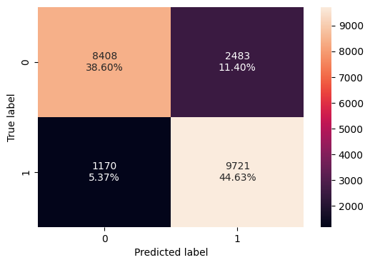

```python
# Plotting confusion matrix for tuned Bagging Classifier on oversampled training data
confusion_matrix(bagging_classifier_tuned, X_train_over, y_train_over)
```

**`Observations:`**

### **Evaluation of model performance on the Validation Set**

```python
# Evaluating tuned Bagging Classifier on validation data
bagging_classifier_tuned_validation_perf = model_performance_evaluation(bagging_classifier_tuned, X_val, y_val)

bagging_classifier_tuned_validation_perf
```

|  | Accuracy | Precision | Recall | F1 Score |
| --- | --- | --- | --- | --- |
| 0 | 0.744175 | 0.77326 | 0.872934 | 0.820079 |

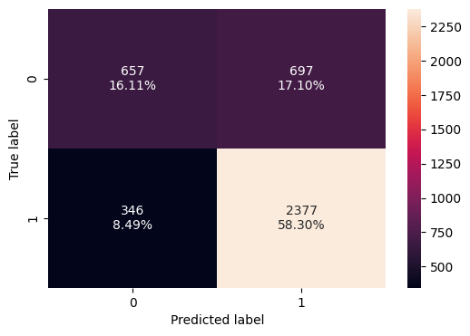

```python
# Plotting confusion matrix for tuned Bagging Classifier on validation data
confusion_matrix(bagging_classifier_tuned, X_val, y_val)
```

**`Observations:`**

## **Hyperparameter Tuning of the RandomForest Classifier**

```python
# Measuring execution time for Random Forest tuning
%%time

# Initializing Random Forest Classifier
random_forest_classifier_tuned = RandomForestClassifier(random_state = 42)

# Defining hyperparameter search space
param_grid = {
    'n_estimators': np.arange(100, 501, 100),
    'criterion': ['gini', 'entropy'],
    'max_depth': np.arange(5, 31, 5),
    'min_samples_split': np.arange(2, 21, 2),
    'min_samples_leaf': np.arange(1, 11, 2),
    'max_features': ['sqrt', 'log2', None],
    'bootstrap': [True, False],
    'class_weight': [None, 'balanced']
}

# Creating F1 score as the evaluation metric
acc_scorer = metrics.make_scorer(metrics.f1_score)

# Setting up RandomizedSearchCV for hyperparameter tuning
random_search = RandomizedSearchCV(
    random_forest_classifier_tuned,
    param_grid,
    scoring = acc_scorer,
    cv = 5,
    n_jobs = -1,
    verbose = 2,
    n_iter = 30
)

# Fitting randomized search on training data
random_search.fit(X_train, y_train)

# Selecting the best tuned Random Forest Classifier
random_forest_classifier_tuned = random_search.best_estimator_

# Training the best model on training data
random_forest_classifier_tuned.fit(X_train, y_train)
```

```
Fitting 5 folds for each of 30 candidates, totalling 150 fits
CPU times: user 18.9 s, sys: 1.92 s, total: 20.8 s
Wall time: 26min 28s
```

```
RandomForestClassifier(max_depth=np.int64(10), max_features='log2',
                       min_samples_leaf=np.int64(9),
                       min_samples_split=np.int64(6),
                       n_estimators=np.int64(400), random_state=42)
```

### **Evaluation of model performance on the Training Set**

```python
# Evaluating tuned Random Forest Classifier on training data
random_forest_classifier_tuned_training_perf = model_performance_evaluation(random_forest_classifier_tuned, X_train, y_train)

random_forest_classifier_tuned_training_perf
```

|  | Accuracy | Precision | Recall | F1 Score |
| --- | --- | --- | --- | --- |
| 0 | 0.762985 | 0.783672 | 0.891103 | 0.833942 |

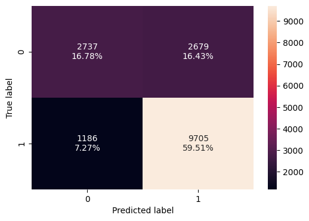

```python
# Plotting confusion matrix for tuned Random Forest Classifier on training data
confusion_matrix(random_forest_classifier_tuned, X_train, y_train)
```

**`Observations:`**

### **Evaluation of model performance on the Validation Set**

```python
# Evaluating tuned Random Forest Classifier on validation data
random_forest_classifier_tuned_validation_perf = model_performance_evaluation(random_forest_classifier_tuned, X_val, y_val)

random_forest_classifier_tuned_validation_perf
```

|  | Accuracy | Precision | Recall | F1 Score |
| --- | --- | --- | --- | --- |
| 0 | 0.745401 | 0.770465 | 0.881381 | 0.822199 |

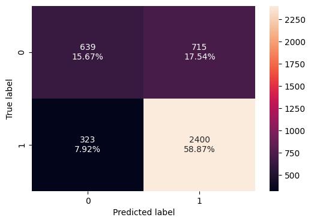

```python
# Plotting confusion matrix for tuned Random Forest Classifier on validation data
confusion_matrix(random_forest_classifier_tuned, X_val, y_val)
```

**`Observations:`**

## **Hyperparameter Tuning of the AdaBoost Classifier**

```python
# Measuring execution time for AdaBoost tuning
%%time

# Initializing AdaBoost Classifier
adaboost_classifier_tuned = AdaBoostClassifier(random_state = 42)

# Defining hyperparameter search space
param_grid = {
    'n_estimators': np.arange(50, 301, 50),
    'learning_rate': np.arange(0.01, 1.01, 0.1),
    'estimator': [
        DecisionTreeClassifier(max_depth=1, random_state=42),
        DecisionTreeClassifier(max_depth=2, random_state=42),
        DecisionTreeClassifier(max_depth=3, random_state=42)]
}

# Creating F1 score as the evaluation metric
acc_scorer = metrics.make_scorer(metrics.f1_score)

# Setting up RandomizedSearchCV for hyperparameter tuning
random_search = RandomizedSearchCV(
    adaboost_classifier_tuned,
    param_grid,
    scoring = acc_scorer,
    cv = 5,
    n_jobs = -1,
    verbose = 2,
    n_iter = 30
)

# Fitting randomized search on training data
random_search.fit(X_train, y_train)

# Selecting the best tuned AdaBoost Classifier
adaboost_classifier_tuned = random_search.best_estimator_

# Training the best model on training data
adaboost_classifier_tuned.fit(X_train, y_train)
```

```
Fitting 5 folds for each of 30 candidates, totalling 150 fits
CPU times: user 10.7 s, sys: 1.42 s, total: 12.2 s
Wall time: 7min 16s
```

```
AdaBoostClassifier(estimator=DecisionTreeClassifier(max_depth=3,
                                                    random_state=42),
                   learning_rate=np.float64(0.11), n_estimators=np.int64(100),
                   random_state=42)
```

### **Evaluation of model performance on the Training Set**

```python
# Evaluating tuned AdaBoost Classifier on training data
adaboost_classifier_tuned_training_perf = model_performance_evaluation(adaboost_classifier_tuned, X_train, y_train)

adaboost_classifier_tuned_training_perf
```

|  | Accuracy | Precision | Recall | F1 Score |
| --- | --- | --- | --- | --- |
| 0 | 0.751763 | 0.779969 | 0.875218 | 0.824853 |

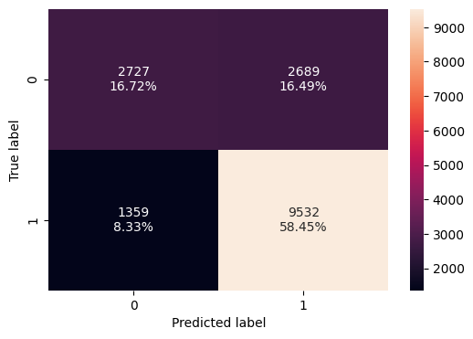

```python
# Plotting confusion matrix for tuned AdaBoost Classifier on training data
confusion_matrix(adaboost_classifier_tuned, X_train, y_train)
```

**`Observations:`**

- The tuned AdaBoost Classifier achieved a training accuracy of 0.7518, indicating that the model correctly classified around 75.2 percent of the training records.
- The precision score is 0.7800, which means that among the records predicted as Certified, around 78.0 percent were actually Certified.
- The recall score is 0.8752, showing that the model correctly identified a large proportion of actual Certified applications.
- The F1 score is 0.8249, which indicates a strong balance between precision and recall on the training data.
- From the confusion matrix, the model correctly classified 2,727 Denied cases and 9,532 Certified cases. However, it misclassified 2,689 Denied cases as Certified and 1,359 Certified cases as Denied.
- The model is better at identifying Certified applications than Denied applications, as the number of correctly predicted Certified cases is much higher than the correctly predicted Denied cases.
- Overall, the tuned AdaBoost Classifier shows balanced training performance with high recall, meaning it is effective in capturing Certified cases while maintaining reasonable precision.

### **Evaluation of model performance on the Validation Set**

```python
# Evaluating tuned AdaBoost Classifier on validation data
adaboost_classifier_tuned_validation_perf = model_performance_evaluation(adaboost_classifier_tuned, X_val, y_val)

adaboost_classifier_tuned_validation_perf
```

|  | Accuracy | Precision | Recall | F1 Score |
| --- | --- | --- | --- | --- |
| 0 | 0.741967 | 0.770301 | 0.874403 | 0.819057 |

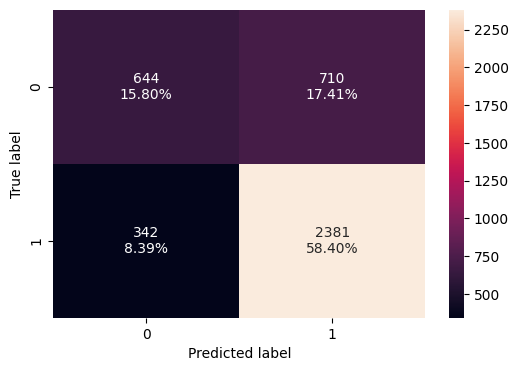

```python
# Plotting confusion matrix for tuned AdaBoost Classifier on validation data
confusion_matrix(adaboost_classifier_tuned, X_val, y_val)
```

**`Observations:`**

- The tuned AdaBoost Classifier achieved a validation accuracy of 0.7420, meaning it correctly classified around 74.2 percent of the validation records.
- The precision score is 0.7703, indicating that when the model predicted an application as Certified, around 77.0 percent of those predictions were correct.
- The recall score is 0.8744, showing that the model successfully identified most of the actual Certified applications in the validation set. The F1 score is 0.8191, which reflects a strong balance between precision and recall on unseen validation data.
- From the confusion matrix, the model correctly classified 644 Denied cases and 2,381 Certified cases. However, it misclassified 710 Denied cases as Certified and 342 Certified cases as Denied.
- The model performs better in identifying Certified cases than Denied cases, as the number of true positives is high while the number of missed Certified cases is relatively low.
- Compared with its training performance, the validation results are very close, which indicates that the tuned AdaBoost model generalizes well and does not show major overfitting.